# Blade’s ground-travel expenses analysis

Zoe Huang

# 1 Executive Summary

The goal of the report is to use the analytical techniques and frameworks to develop insights about the company’s employees and expenses, which could then be leveraged to reduce the cost of employee ground-travel. The analysis is based on the data set for a portion of Blade’s ground-travel expenses for June – Aug 2019. Top 3 conclusions from the data:

**Conclusion 1:** Different Services have different average transaction amount either by distance or by duration. Also, on average, different expense reason would cost differently per transaction.

**Conclusion 2:** In terms of the total transaction amount and the total number of transactions, New York City ranks the highest, followed by NYC suburbs. However, NYC has a relatively low average transaction amount, while NYC suburs ranks the highest.

**Conclusion 3:** The average transaction amount is the highest on Sunday, while the number of transactions on Friday is the highest.

# 2 Reasoning and Backup

## 2.1 Conclusion 1

**Conclusion 1:** Different Services have different average transaction amount either by distance or by duration. Also, on average, different expense reason would cost differently per transaction.

Below is the analysis:

**1. Expenses by Program**

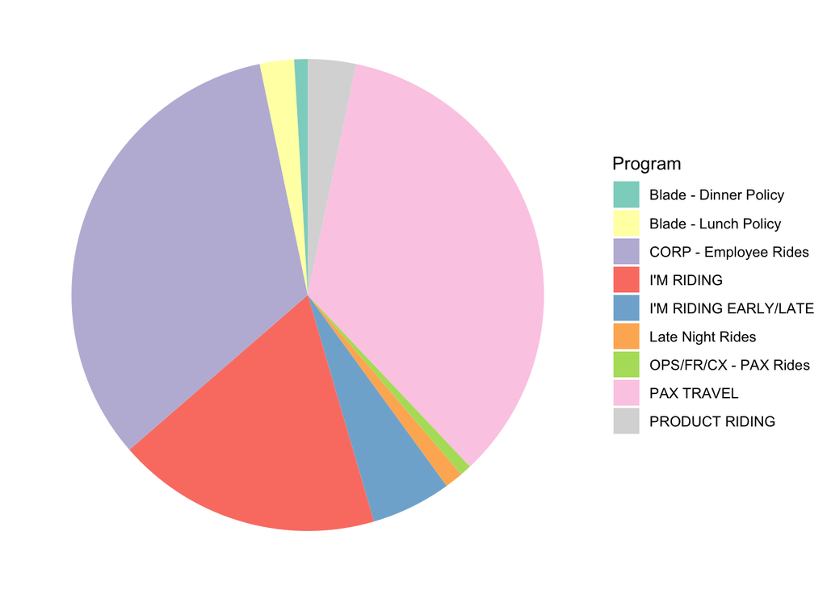

Out of the total transaction amount, most of them are from “PAX TRAVEL” Program, followed by “CORP - Employee Rides” Program and “I’M RIDING” Program. These three programs also have the highest number of transactions among all the nine programs.

**2. Expenses by Service**

|  | Service | N | Mean_Amount_by_distance | Mean_Amount_by_duration |
| --- | --- | --- | --- | --- |
| 1 | Travel \| UberX | 971 | 8.34 | 1.71 |
| 2 | Travel \| UberX Diamond | 647 | 12.27 | 1.76 |
| 3 | Travel \| Black SUV | 304 | 77.78 | 4.6 |
| 4 | Eats | 202 | 26.2 | 0.85 |
| 5 | Travel \| Premium SUV | 184 | 96.04 | 4.04 |
| 6 | Travel \| Black | 60 | 18.32 | 3.15 |
| 7 | Travel \| UberXL | 41 | 26.92 | 3.66 |
| 8 | Travel \| Premium | 20 | 70.2 | 3.84 |
| 9 | Central \| UberX | 8 | 7.05 | 1.64 |
| 10 | Travel \| UberX VIP | 6 | 6.62 | 1.45 |

[output cut: 5 more lines]

Most of the transactions are using the service of “Travel | UberX”, while some other services have only less than 5 transactions. On average, the service of “Travel | Premium SUV” would cost the most by distance (per mi) compared to others and the service of “Travel | Black SUV” would cost the most by duration (per min) compared to others.

**3. Expenses by Reason**

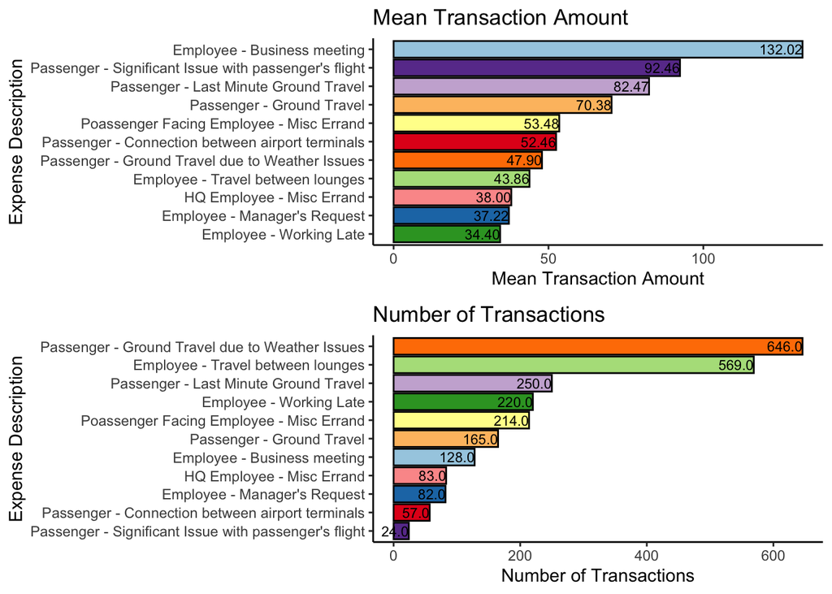

## 2.2 Conclusion 2

**Conclusion 2:** In terms of the total transaction amount and the total number of transactions, New York City ranks the highest, followed by NYC suburbs. However, NYC has a relatively low average transaction amount, while NYC suburs ranks the highest.

Below is the analysis:

**1. Expenses of each employee**

Now let’s do some investigation regarding employees and their espenses We will start by computing the transaction times, the total and average expenses amount by employee ID.

|  | Last.Name | First.Name | lookup | N | Total_Amount | Avg_Amount |
| --- | --- | --- | --- | --- | --- | --- |
| 1 | McNeil | Torey | Torey_McNeil | 211 | 13442.64 | 63.71 |
| 2 | Rooney | Jess | Jess_Rooney | 143 | 6767.36 | 47.32 |
| 3 | Thompson | Cal | Cal_Thompson | 142 | 10141.34 | 71.42 |
| 4 | Pelczar | Evelyn | Evelyn_Pelczar | 114 | 3705.81 | 32.51 |
| 5 | Mirto | Jake | Jake_Mirto | 110 | 10368.5 | 94.26 |
| 6 | Orlov | Oksana | Oksana_Orlov | 108 | 4463.72 | 41.33 |
| 7 | Senning | Hunter | Hunter_Senning | 104 | 5781.65 | 55.59 |
| 8 | Brody | Matthew | Matthew_Brody | 103 | 5412.69 | 52.55 |
| 9 | Tam | Bowie | Bowie_Tam | 87 | 5463.1 | 62.79 |
| 10 | Alexander | Nate | Nate_Alexander | 86 | 4137.89 | 48.11 |

[output cut: 46 more lines]

Among the 56 employees, McNeil Torey has the greatest number of transactions and the highest total transaction amount, even though McNeil Torey doesn’t have the highest average transaction amount. Meyer Joseph only has 7 transactions but on average, the transaction amount is the highest, almost twice as much as the second highest average transaction amount from Friedman Madison.

**2. Expenses of each city**

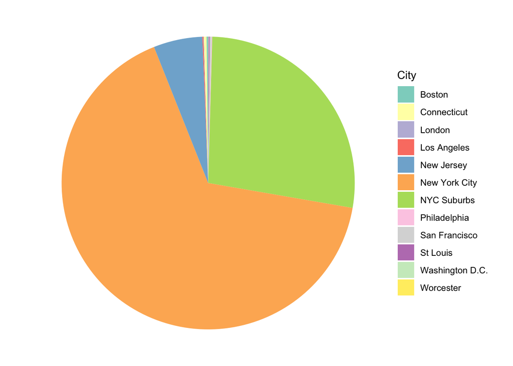

Out of the total transaction amount, most of them are from New York City, followed by NYC suburbs.

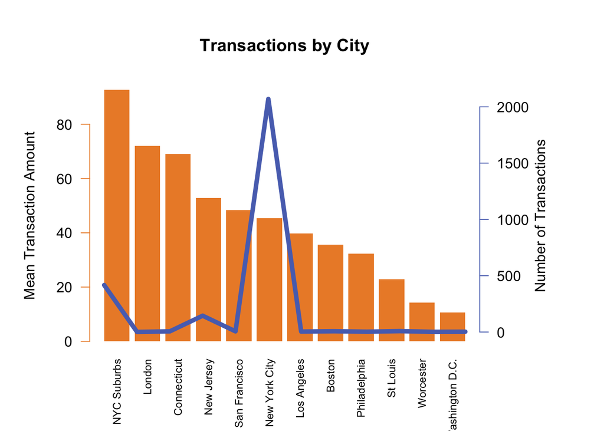

Also, most transactions happened in New York City, followed by NYC suburbs. NYC suburbs has the highest average transaction amount followed by London and Connecticut, which do not have a high number transactions. This makes sense because the value of the per diems varies with different locations. New York City is expensive compared to Las Vegas, for example. Smaller, non-resort areas are even more affordable.

## 2.3 Conclusion 3

**Conclusion 3:** The average transaction amount is the highest on Sunday, while the number of transactions on Friday is the highest. Normally on workdays, the peak duration within a day is from 18:00 to 23:00.

Below is the analysis:

**1. Expenses of each day**

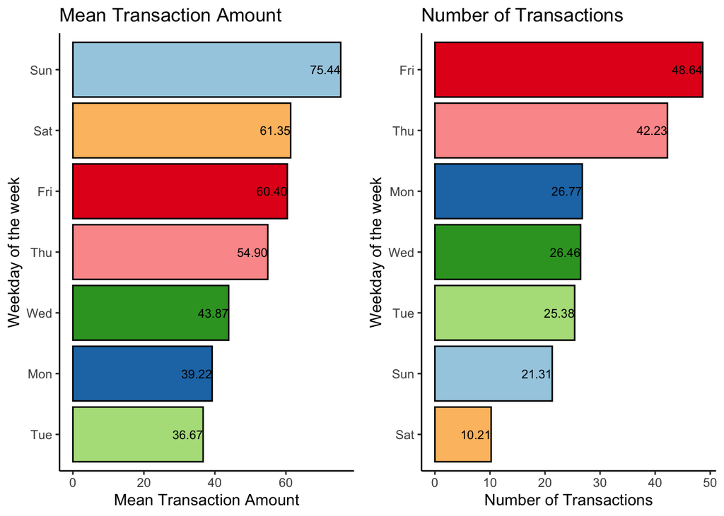

**2. Expenses by day of week and hour**

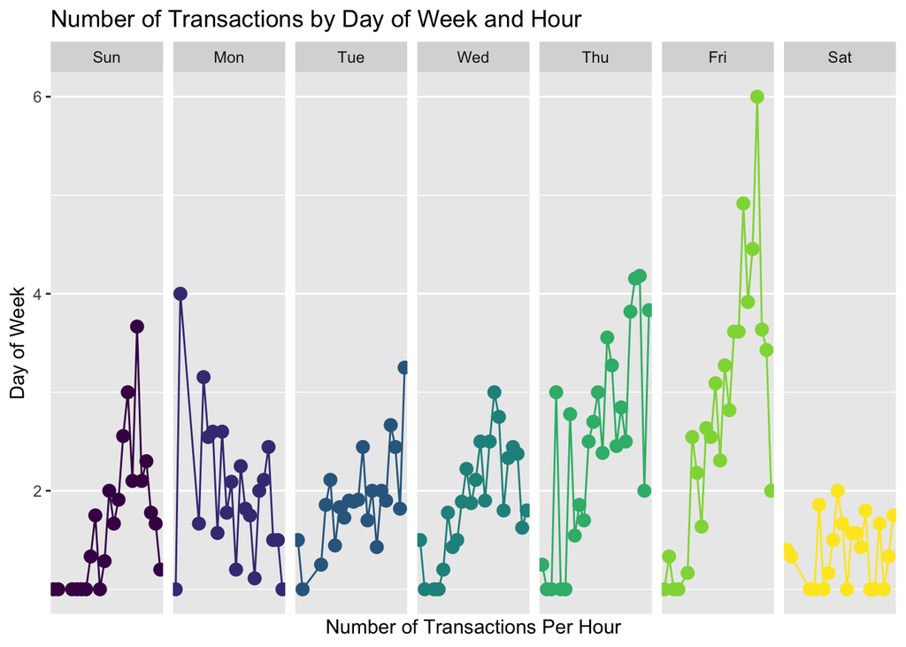

From Tuesday to Friday, the number of orders per hour on average would be peak during 18:00 to 23:00, while on Monday, the peak period is from 0 to 4:00. On Saturday, the number of orders within a day is lower than that of the other weekdays.

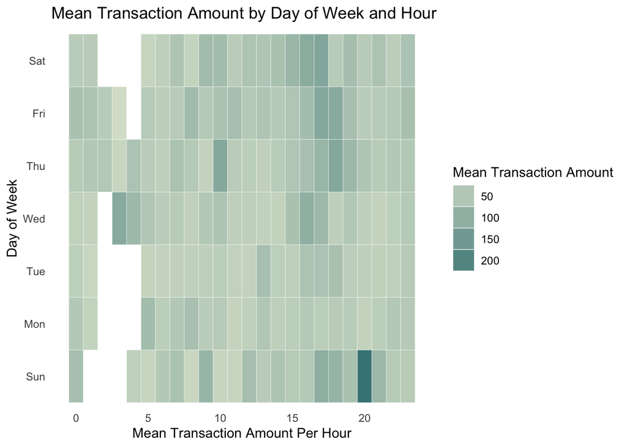

The average transaction amount per hour at 20:00 on Sunday is the highest, compared to other periods.

# 3 Action Items

**1. Use cheaper service:** For long-distance travel, encourage employees to avoid using “Travel | Premium SUV”, “Travel | Black SUV”, and “Travel | Premium”. Encouraging the use of affordable ground transportation options (including public transportation) can reduce costs in this often-overlooked expense category.

**2. Use virtual meetings, services such as Skype for Business, and videos:** Business meetings always cost the most. Even though face-to-face meetings are sometimes essential, it’s easier and cheaper than ever to have a teleconference with clients or co-workers in different cities. Therefore, in order to reduce the cost, the company should consider switching to virtual meetings if possible. Webinars work well for various kinds of training, especially seminars that allow multiple employees to attend.

**3. Set up a budget for each employee/department:** Establish and enforce a strict but reasonable travel reimbursement policy that’s fair to all employees. Ask adult employees to make timely reservations, budget expenses on their business trips, and explore options other than travel for meetings and training.

**4. Book travel as much ahead of time as possible:** Last-minute bookings are expensive. Sometimes, on Friday night, the rate would be more expensive too. Employees could save just by being flexible on the dates of travel and the time of booking.

In summary, by switching to affordable ground transportation options, making use of virtual meetings services, tightening up a reimbursement policy, and scheduling wisely, companies can remain agile and practical when it comes to costs associated with employee travel. And above all, when employees understand that their organization’s business travel policies are designed to be fair, eliminate unnecessary spending, and reduce risk, they’ll be much more likely to plan trips well in advance and only make the necessary expenses when they do need to travel.